# Simple Linear Regression III

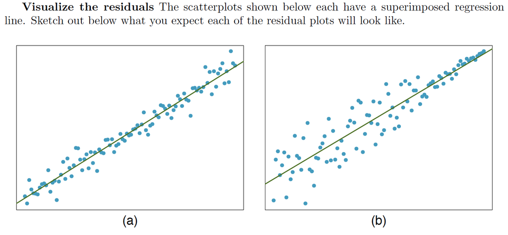

## Outliers

## What is an outlier?

[figure not shown]

**Outlier** is a general term to describe a data point that doesn't follow the pattern set by the bulk of the data, when one takes into account the model.

## Outlier Example One

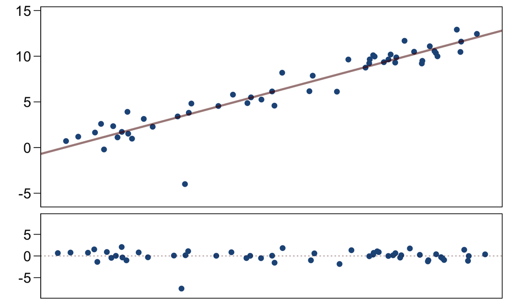

## Outlier Example Two

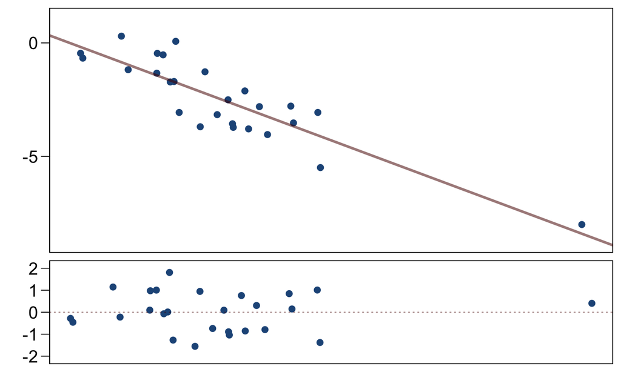

## Outlier Example Three

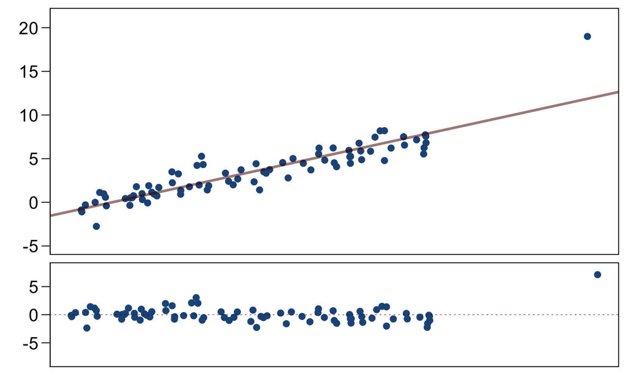

## Outlier Example Four

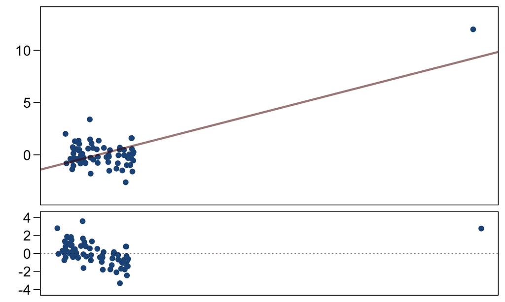

## Outlier Example Four

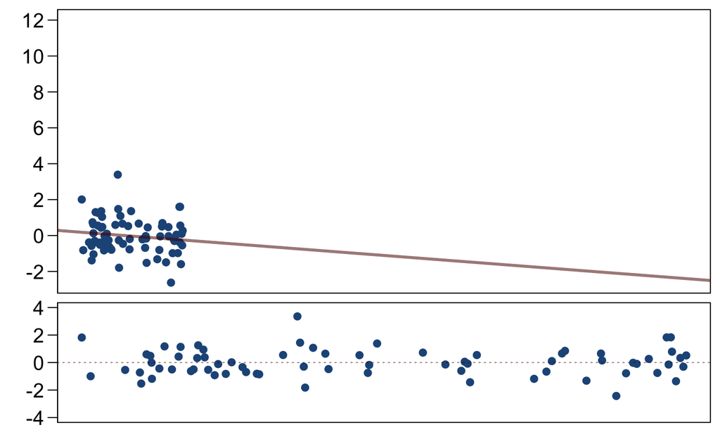

## Outliers, leverage, influence

**Outliers** are points that don't fit the trend in the rest of the data.

**High leverage points** have the potential to have an unusually large influence on the fitted model.

**Influential points** are high leverage points that cause a very different line to be fit than would be with that point removed.

## Example of high lev, high influence

We have data on the surface temperature and light intensity of 47 stars in the star cluster CYG OB1, near Cygnus.

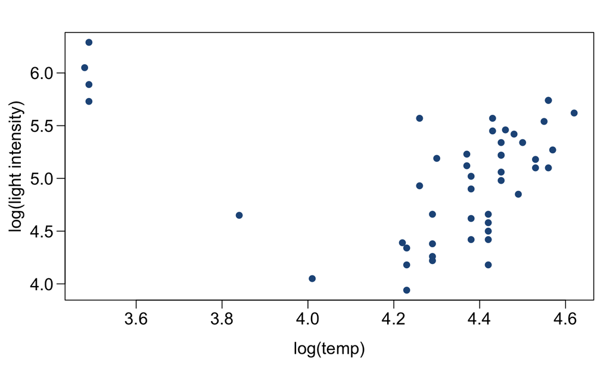

## Example of high lev, high influence

We have data on the surface temperature and light intensity of 47 stars in the star cluster CYG OB1, near Cygnus.

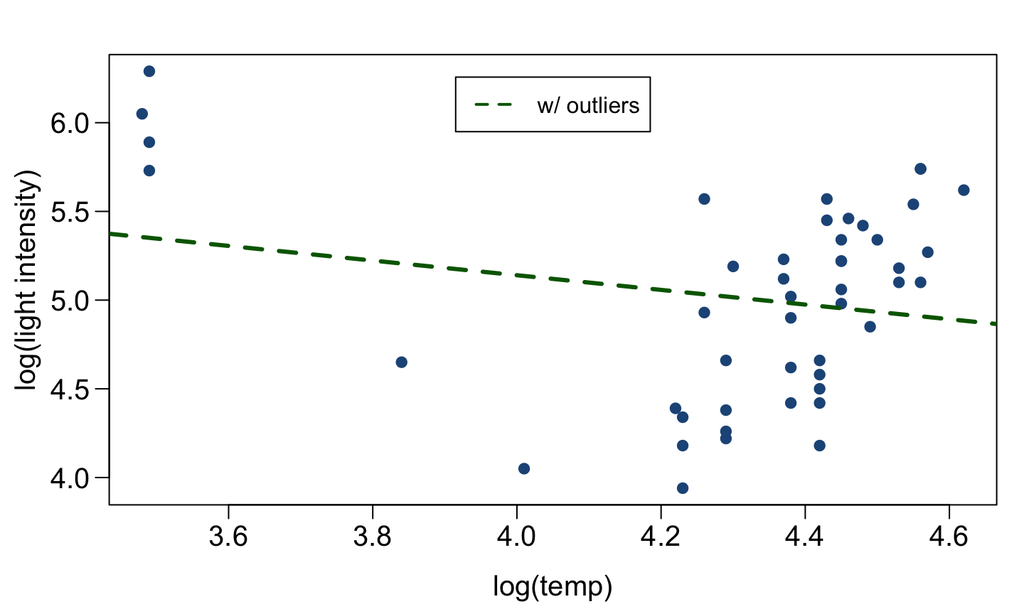

## Example of high lev, high influence

We have data on the surface temperature and light intensity of 47 stars in the star cluster CYG OB1, near Cygnus.

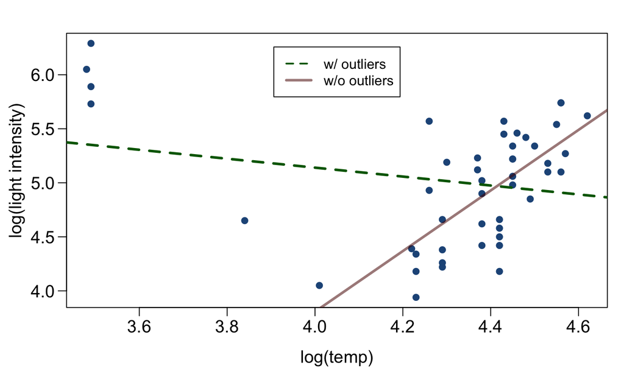

## Example of high lev, low influence

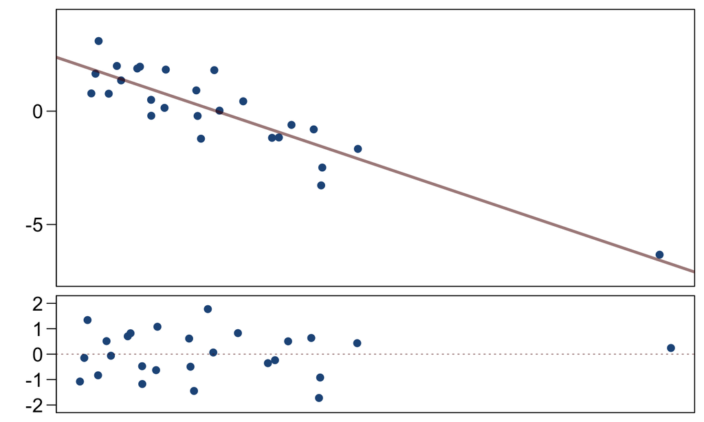

## From leverage to influence

**Leverage** measures the weight given to each point in determining the regression line.

**Influence** measures how different the regression line would be without a given point. Often measured with *Cook's Distance*.

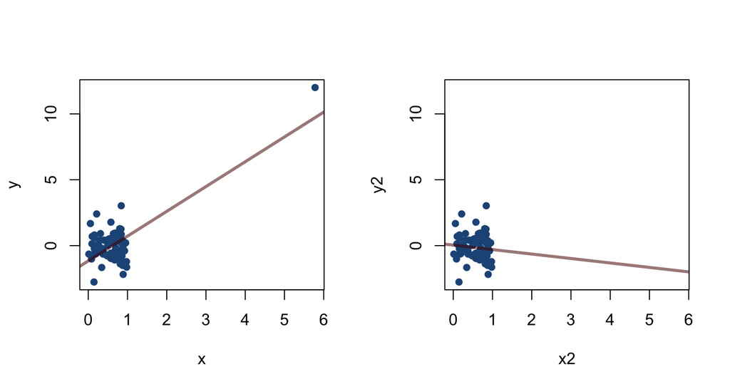

In the following plots are there outliers, leverage pts, or influential pts?

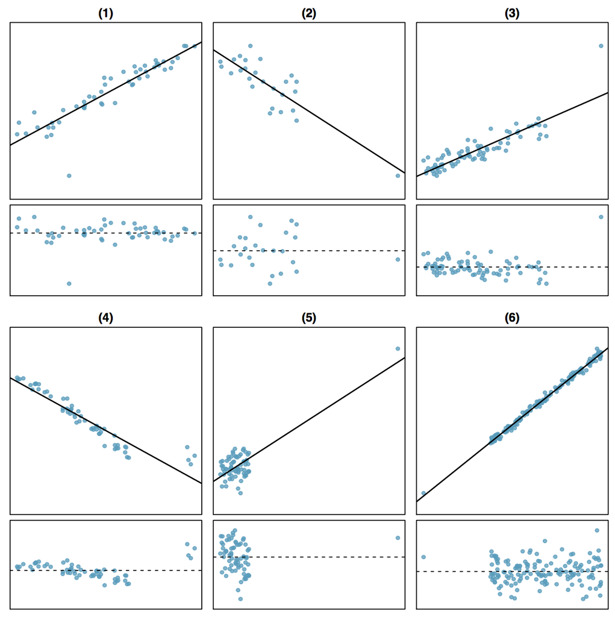